# Website Conversion Predictability

Raj Goel  
August 2024

## Executive Summary

The EdTech industry has been surging in the past decade immensely, and according to a forecast, the Online Education market would be worth $286.62bn by 2023 with a compound annual growth rate (CAGR) of 10.26% from 2018 to 2023. The modern era of online education has enforced a lot in its growth and expansion beyond any limit. Due to having many dominant features like ease of information sharing, personalized learning experience, transparency of assessment, etc, it is now preferable to traditional education.

In the present scenario due to the Covid-19, the online education sector has witnessed rapid growth and is attracting a lot of new customers. Due to this rapid growth, many new companies have emerged in this industry. With the availability and ease of use of digital marketing resources, companies can reach out to a wider audience with their offerings. The customers who show interest in these offerings are termed as leads. There are various sources of obtaining leads for Edtech companies, like

- The customer interacts with the marketing front on social media or other online platforms.
- The customer browses the website/app and downloads the brochure
- The customer connects through emails for more information.

The company then nurtures these leads and tries to convert them to paid customers. For this, the representative from the organization connects with the lead on call or through email to share further details.

## Objective

ExtraaLearn is an initial stage startup that offers programs on cutting-edge technologies to students and professionals to help them upskill/reskill. With a large number of leads being generated regularly, one of the issues faced by ExtraaLearn is to identify which of the leads are more likely to convert so that they can allocate resources accordingly. You, as a data scientist at ExtraaLearn, have been provided the leads data to:

- Analyze and build an ML model to help identify which leads are more likely to convert to paid customers,
- Find the factors driving the lead conversion process
- Create a profile of the leads which are likely to convert

## Data Description

The data contains the different attributes of leads and their interaction details with ExtraaLearn. The detailed data dictionary is given below.

**Data Dictionary**

- ID: ID of the lead
- age: Age of the lead
- current_occupation: Current occupation of the lead. Values include 'Professional','Unemployed',and 'Student'
- first_interaction: How did the lead first interact with ExtraaLearn. Values include 'Website', 'Mobile App'
- profile_completed: What percentage of the profile has been filled by the lead on the website/mobile app. Values include Low - (0-50%), Medium - (50-75%), High (75-100%)
- website_visits: How many times has a lead visited the website
- time_spent_on_website: Total time spent on the website
- page_views_per_visit: Average number of pages on the website viewed during the visits.
- last_activity: Last interaction between the lead and ExtraaLearn.
  - Email Activity: Seeking for details about the program through email, Representative shared information with a lead like a brochure of program, etc
  - Phone Activity: Had a Phone Conversation with a representative, Had conversation over SMS with a representative, etc
  - Website Activity: Interacted on live chat with a representative, Updated profile on the website, etc
- print_media_type1: Flag indicating whether the lead had seen the ad of ExtraaLearn in the Newspaper.
- print_media_type2: Flag indicating whether the lead had seen the ad of ExtraaLearn in the Magazine.
- digital_media: Flag indicating whether the lead had seen the ad of ExtraaLearn on the digital platforms.
- educational_channels: Flag indicating whether the lead had heard about ExtraaLearn in the education channels like online forums, discussion threads, educational websites, etc.
- referral: Flag indicating whether the lead had heard about ExtraaLearn through reference.
- status: Flag indicating whether the lead was converted to a paid customer or not.

```python
from google.colab import drive

import pandas as pd
import numpy as np

# libaries to help with data visualization
import matplotlib.pyplot as plt
import seaborn as sns

# To build model for prediction
from sklearn.model_selection import train_test_split
from sklearn.tree import DecisionTreeClassifier
from sklearn.ensemble import RandomForestClassifier
from sklearn import tree
from sklearn import metrics
from sklearn import ensemble

# To tune different models
from sklearn.model_selection import GridSearchCV

# To get diferent metric scores
from sklearn.metrics import (
    f1_score,
    accuracy_score,
    recall_score,
    precision_score,
    confusion_matrix,
    classification_report,
    precision_recall_curve,
    roc_curve,
    make_scorer,
)
```

```python
import warnings

warnings.filterwarnings("ignore")
from statsmodels.tools.sm_exceptions import ConvergenceWarning

warnings.simplefilter("ignore", ConvergenceWarning)
```

## Import Dataset

```python
# Read the data from CSV file
drive.mount('/content/drive', force_remount = True)
data1 = pd.read_csv("/content/drive/MyDrive/CSV Files/PDS.csv")
```

```python
# Copying data to another variable to avoid any changes to original data
data = data1.copy()
```

```python
# How many rows and columns in the data?
print("The data has", data.shape[0], "rows and", data.shape[1], "columns.")
```

```
The data has 4612 rows and 15 columns.
```

```python
# What are the data types for the different columns?
data.info()
```

```
<class 'pandas.core.frame.DataFrame'>
RangeIndex: 4612 entries, 0 to 4611
Data columns (total 15 columns):
 #   Column                 Non-Null Count  Dtype
---  ------                 --------------  -----
 0   ID                     4612 non-null   object
 1   age                    4612 non-null   int64
 2   current_occupation     4612 non-null   object
 3   first_interaction      4612 non-null   object
 4   profile_completed      4612 non-null   object
 5   website_visits         4612 non-null   int64
 6   time_spent_on_website  4612 non-null   int64
 7   page_views_per_visit   4612 non-null   float64
 8   last_activity          4612 non-null   object
 9   print_media_type1      4612 non-null   object
 10  print_media_type2      4612 non-null   object
 11  digital_media          4612 non-null   object
 12  educational_channels   4612 non-null   object
 13  referral               4612 non-null   object
 14  status                 4612 non-null   int64
dtypes: float64(1), int64(4), object(10)
memory usage: 540.6+ KB
```

```python
# Check for duplicate values in the data
data.duplicated()
```

```
0       False
1       False
2       False
3       False
4       False
        ...
4607    False
4608    False
4609    False
4610    False
4611    False
Length: 4612, dtype: bool
```

```python
# ID column does not add any value to the analysis, so we can drop it
data.drop(["ID"], axis=1, inplace=True)
```

### Observations

1. There are 4612 rows and 15 columns in the data set.
2. There are no missing values.
3. There are no duplicates.
4. We can drop the "ID" column because it doesn't add any value for our analysis.

## Exploratory Data Analysis

Let's check the statistical summary of the data.

```python
# Print the statistical summary of the data
data.describe()
```

|  | age | website_visits | time_spent_on_website | page_views_per_visit | status |
| --- | --- | --- | --- | --- | --- |
| count | 4612.000000 | 4612.000000 | 4612.000000 | 4612.000000 | 4612.000000 |
| mean | 46.201214 | 3.566782 | 724.011275 | 3.026126 | 0.298569 |
| std | 13.161454 | 2.829134 | 743.828683 | 1.968125 | 0.457680 |
| min | 18.000000 | 0.000000 | 0.000000 | 0.000000 | 0.000000 |
| 25% | 36.000000 | 2.000000 | 148.750000 | 2.077750 | 0.000000 |
| 50% | 51.000000 | 3.000000 | 376.000000 | 2.792000 | 0.000000 |
| 75% | 57.000000 | 5.000000 | 1336.750000 | 3.756250 | 1.000000 |
| max | 63.000000 | 30.000000 | 2537.000000 | 18.434000 | 1.000000 |

### Univariate Analysis

```python
# function to plot a boxplot and a histogram along the same scale.

def histogram_boxplot(data, feature, figsize=(12, 7), kde=False, bins=None):
    """
    Boxplot and histogram combined

    data: dataframe
    feature: dataframe column
    figsize: size of figure (default (12,7))
    kde: whether to the show density curve (default False)
    bins: number of bins for histogram (default None)
    """
    f2, (ax_box2, ax_hist2) = plt.subplots(
        nrows=2,  # Number of rows of the subplot grid= 2
        sharex=True,  # x-axis will be shared among all subplots
        gridspec_kw={"height_ratios": (0.25, 0.75)},
        figsize=figsize,
    )  # creating the 2 subplots
    sns.boxplot(
        data=data, x=feature, ax=ax_box2, showmeans=True, color="violet"
    )  # boxplot will be created and a star will indicate the mean value of the column
    sns.histplot(
        data=data, x=feature, kde=kde, ax=ax_hist2, bins=bins, palette="winter"
    ) if bins else sns.histplot(
        data=data, x=feature, kde=kde, ax=ax_hist2
    )  # For histogram
    ax_hist2.axvline(
        data[feature].mean(), color="green", linestyle="--"
    )  # Add mean to the histogram
    ax_hist2.axvline(
        data[feature].median(), color="black", linestyle="-"
    )  # Add median to the histogram
```

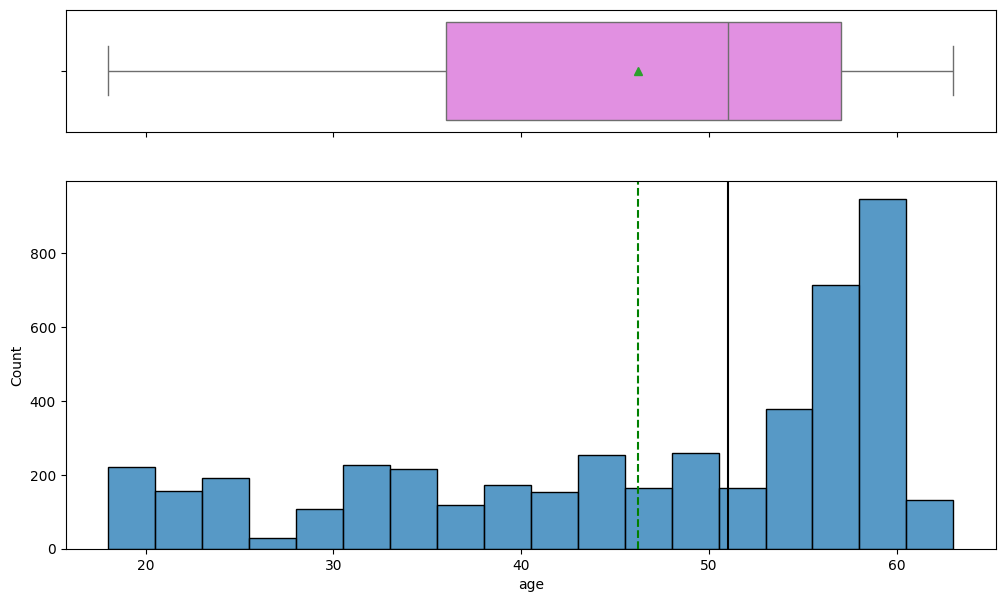

```python
histogram_boxplot(data, "age")
```

### Observations on age

Average age of visitors is around 46

Median age of visitors is 51

Majority of website visitors are between 36 and 57 years old.

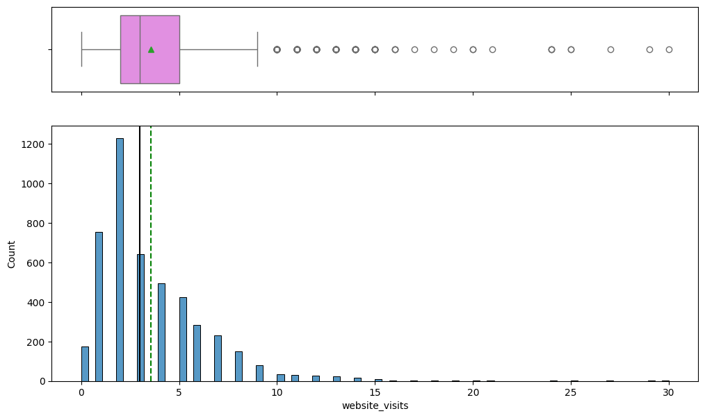

```python
# plot a histogram_boxplot for website_visits
histogram_boxplot(data, "website_visits")
```

### Observations on website_visits

1. Average website visits was 3.5
2. Median website visits was 3
3. 174 leads did not visit the website at all

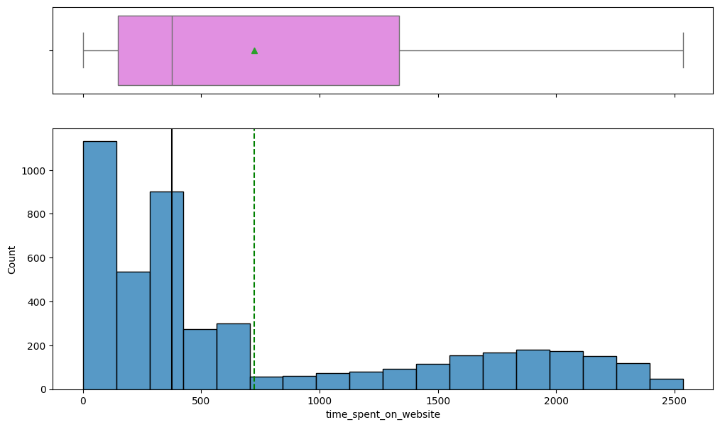

```python
# plot a histogram_boxplot for time_spent_on_website
histogram_boxplot(data, "time_spent_on_website")
```

### Observations on time_spent_on_website

1. Average time spent on website was 750
2. Median time spent on website was around 400
3. Majority of time spent was between 150 and 1350
4. We observe a long tail of users spending 1500-2500 time on the website

(Time units have not been specified anywhere, so I am not mentioning the time units above)

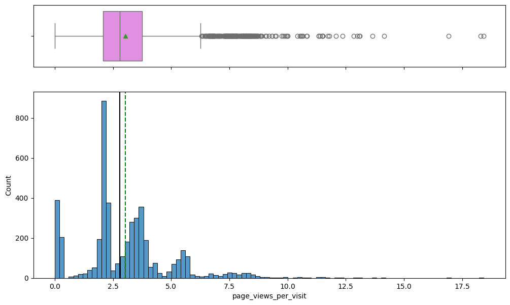

```python
# plot a histogram_boxplot for page_views_per_visit
histogram_boxplot(data, "page_views_per_visit")
```

### Observations on number of page_views_per_visit

1. Average page views per visit was 3
2. Median page views per visit was 2.8
3. Majority of page views per visit were between 2.2 and 3.7
4. There is a long tail of page views per visit > 6.5

```python
# function to create labeled barplots

def labeled_barplot(data, feature, perc=False, n=None):
    """
    Barplot with percentage at the top

    data: dataframe
    feature: dataframe column
    perc: whether to display percentages instead of count (default is False)
    n: displays the top n category levels (default is None, i.e., display all levels)
    """

    total = len(data[feature])  # length of the column
    count = data[feature].nunique()
    if n is None:
        plt.figure(figsize=(count + 1, 5))
    else:
        plt.figure(figsize=(n + 1, 5))

    plt.xticks(rotation=90, fontsize=15)
    ax = sns.countplot(
        data=data,
        x=feature,
        palette="Paired",
        order=data[feature].value_counts().index[:n].sort_values(),
    )

    for p in ax.patches:
        if perc == True:
            label = "{:.1f}%".format(
                100 * p.get_height() / total
            )  # percentage of each class of the category
        else:
            label = p.get_height()  # count of each level of the category

        x = p.get_x() + p.get_width() / 2  # width of the plot
        y = p.get_height()  # height of the plot

        ax.annotate(
            label,
            (x, y),
            ha="center",
            va="center",
            size=12,
            xytext=(0, 5),
            textcoords="offset points",
        )  # annotate the percentage

    plt.show()  # show the plot
```

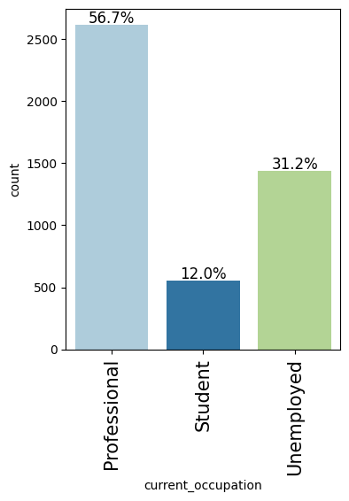

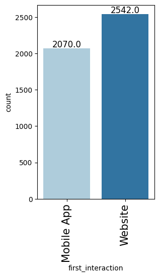

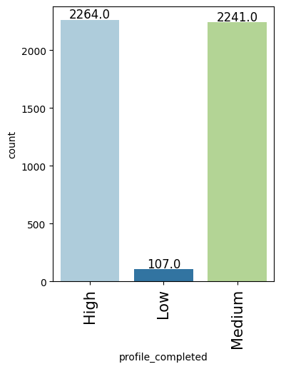

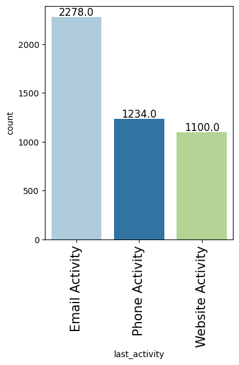

```python
# plot labeled_barplot for current_occupation
labeled_barplot(data, "current_occupation", perc=True)
print()

# plot labeled_barplot for first_interaction
labeled_barplot(data, "first_interaction")
print()

# plot labeled_barplot for profile_completed
labeled_barplot(data, "profile_completed")
print()

# Plot labeled_barplot for last_activity
labeled_barplot(data, "last_activity")
```

### Observations

1. Majority of leads are professionals, followed by unemployed, followed by students.
2. More leads had website as the first interaction, as opposed to mobile app.
3. Most leads completed 50% or more of their profile.
4. Majority of leads had email activity as their last activity with the company. It hasn't been mentioned whether last_activity was the user's last activity before conversion, or whether last_activity was just a snapshot in time, so it's not possible to derive any meaningful information from this data except that email is a very important medium of communication for the company.

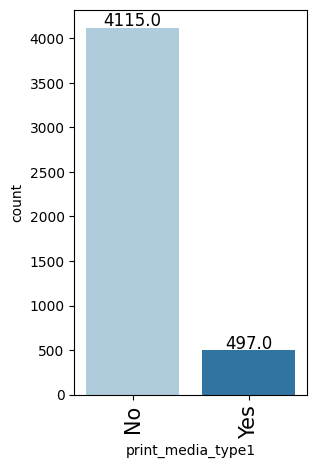

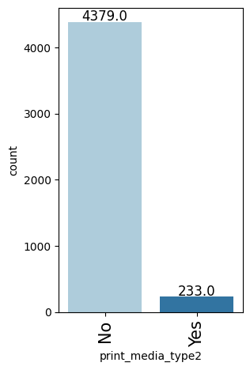

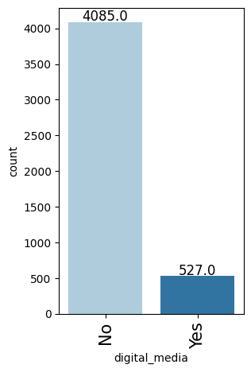

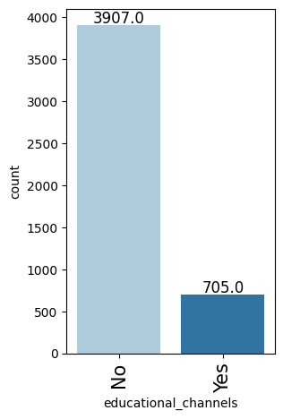

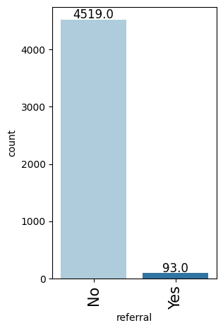

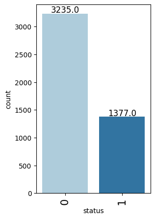

```python
# plot labeled_barplot for print_media_type1
labeled_barplot(data, "print_media_type1")
print()

# plot labeled_barplot for print_media_type2
labeled_barplot(data, "print_media_type2")
print()

# plot labeled_barplot for digital_media
labeled_barplot(data, "digital_media")
print()

# plot labeled_barplot for educational_channels
labeled_barplot(data, "educational_channels")
print()

# plot labeled_barplot for referral
labeled_barplot(data, "referral")
print()

# plot labeled_barplot for status
labeled_barplot(data, "status")
```

### Observations

1. 10.8% of all leads had seen the ad on print media type 1.
2. 5% of all leads had seen the ad on print media type 2.
3. 11.4% of all leads had seen the ad on digital media.
4. 15.3% of all leads heard about the site from an educational channel.
5. 2% of all leads were from referrals.
6. Overall conversion rate is 1377/4612 = 29.9%

### Bivariate Analysis

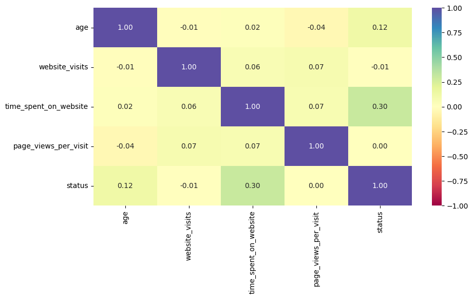

```python
cols_list = data.select_dtypes(include=np.number).columns.tolist()

plt.figure(figsize=(10, 5))
sns.heatmap(
    data[cols_list].corr(), annot=True, vmin=-1, vmax=1, fmt=".2f", cmap="Spectral"
)
plt.show()
```

### Observations

1. There is a clear correlation between time spent on website and conversion.
2. There is a weak correlation between age and correlation.
3. Other correlations do not appear to be significant.

**Creating functions that will help us with further analysis.**

```python
# Function to plot distributions wrt target

def distribution_plot_wrt_target(data, predictor, target):

    fig, axs = plt.subplots(2, 2, figsize=(12, 10))

    target_uniq = data[target].unique()

    axs[0, 0].set_title("Distribution of target for target=" + str(target_uniq[0]))
    sns.histplot(
        data=data[data[target] == target_uniq[0]],
        x=predictor,
        kde=True,
        ax=axs[0, 0],
        color="teal",
        stat="density",
    )

    axs[0, 1].set_title("Distribution of target for target=" + str(target_uniq[1]))
    sns.histplot(
        data=data[data[target] == target_uniq[1]],
        x=predictor,
        kde=True,
        ax=axs[0, 1],
        color="orange",
        stat="density",
    )

    axs[1, 0].set_title("Boxplot w.r.t. target")
    sns.boxplot(data=data, x=target, y=predictor, ax=axs[1, 0], palette="gist_rainbow")

    axs[1, 1].set_title("Boxplot (without outliers) w.r.t. target")
    sns.boxplot(
        data=data,
        x=target,
        y=predictor,
        ax=axs[1, 1],
        showfliers=False,
        palette="gist_rainbow",
    )

    plt.tight_layout()
    plt.show()
```

```python
def stacked_barplot(data, predictor, target):
    """
    Print the category counts and plot a stacked bar chart

    data: dataframe
    predictor: independent variable
    target: target variable
    """
    count = data[predictor].nunique()
    sorter = data[target].value_counts().index[-1]
    tab1 = pd.crosstab(data[predictor], data[target], margins=True).sort_values(
        by=sorter, ascending=False
    )
    print(tab1)
    print("-" * 120)
    tab = pd.crosstab(data[predictor], data[target], normalize="index").sort_values(
        by=sorter, ascending=False
    )
    tab.plot(kind="bar", stacked=True, figsize=(count + 5, 5))
    plt.legend(
        loc="lower left", frameon=False,
    )
    plt.legend(loc="upper left", bbox_to_anchor=(1, 1))
    plt.show()
```

### Observations

Professionals are most likely to convert, and students are least likely to convert. Probably because of affordability, and because professionals know what they need to train on for their job.

```
status                 0     1   All
current_occupation
All                 3235  1377  4612
Professional        1687   929  2616
Unemployed          1058   383  1441
Student              490    65   555
------------------------------------------------------------------------------------------------------------------------
```

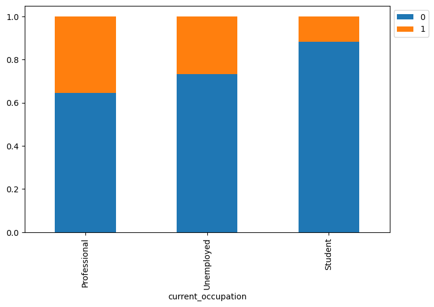

```python
stacked_barplot(data, "current_occupation", "status")
```

```
age                 18  19  20  21  22  23  24  25  26  27  ...   55   56  \
current_occupation                                          ...
Professional         0   0   0   0   0   0   0  16  15  14  ...  134  252
All                 66  81  75  86  71  85  90  17  15  14  ...  200  330
Student             66  81  75  86  71  85  90   1   0   0  ...    0    0
Unemployed           0   0   0   0   0   0   0   0   0   0  ...   66   78

age                  57   58   59   60  61  62  63   All
current_occupation
Professional        282  256  217  135   0   0   0  2616
All                 385  382  328  238  38  48  47  4612
Student               0    0    0    0   0   0   0   555
Unemployed          103  126  111  103  38  48  47  1441

[4 rows x 47 columns]
------------------------------------------------------------------------------------------------------------------------
```

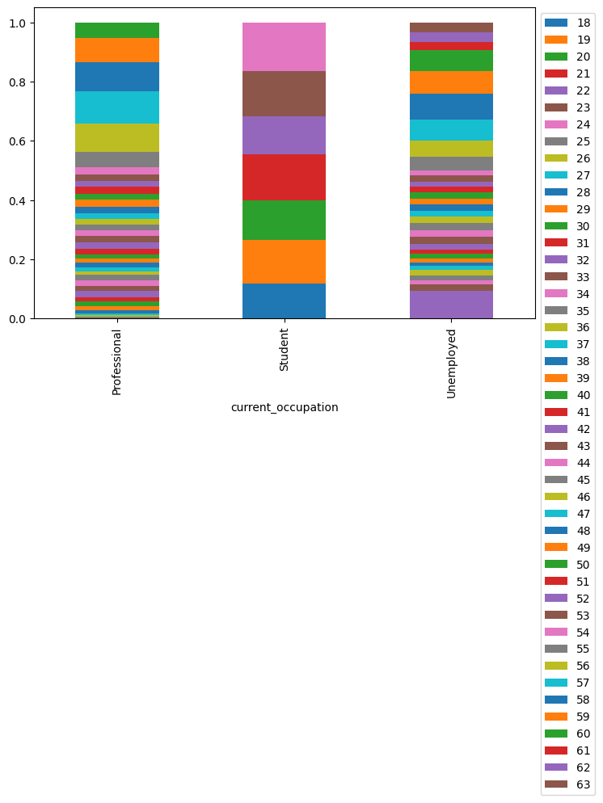

```python
plt.figure(figsize=(10, 5))
stacked_barplot(data, "current_occupation", "age")
plt.show()
```

```python
data.groupby(["current_occupation"])["age"].describe()
```

| current_occupation | count | mean | std | min | 25% | 50% | 75% | max |
| --- | --- | --- | --- | --- | --- | --- | --- | --- |
| Professional | 2616.0 | 49.347477 | 9.890744 | 25.0 | 42.0 | 54.0 | 57.0 | 60.0 |
| Student | 555.0 | 21.144144 | 2.001114 | 18.0 | 19.0 | 21.0 | 23.0 | 25.0 |
| Unemployed | 1441.0 | 50.140180 | 9.999503 | 32.0 | 42.0 | 54.0 | 58.0 | 63.0 |

```
status                0     1   All
first_interaction
All                3235  1377  4612
Website            1383  1159  2542
Mobile App         1852   218  2070
------------------------------------------------------------------------------------------------------------------------
```

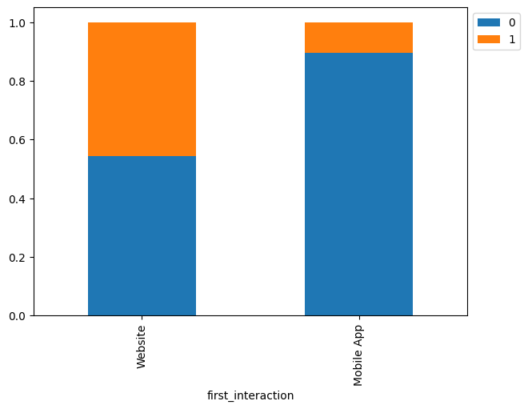

```python
# plot stacked_barplot for first_interaction and status
stacked_barplot(data, "first_interaction", "status")
```

### Observations

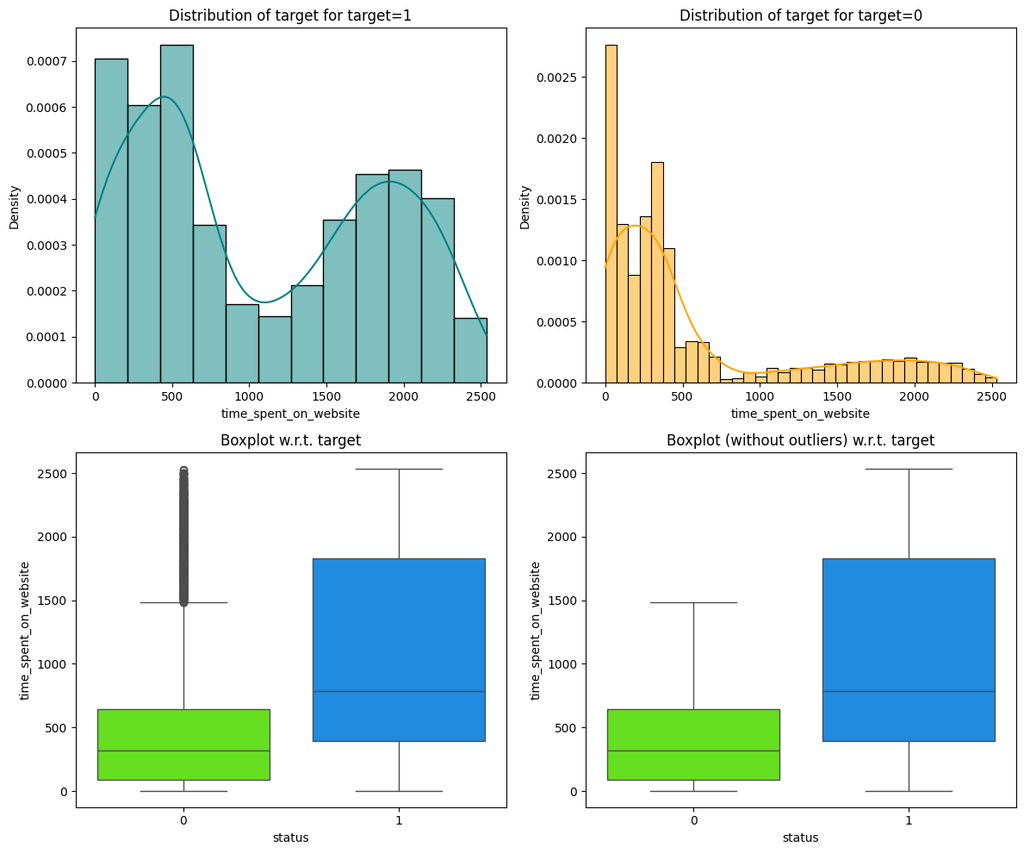

```python
distribution_plot_wrt_target(data, "time_spent_on_website", "status")
```

```python
# Check the median value of time_spent_on_website for conversion
data.groupby(["status"])["time_spent_on_website"].median()
```

```
status
0    317.0
1    789.0
Name: time_spent_on_website, dtype: float64
```

```python
# Check the median value of website_visits for conversion
data.groupby(["status"])["website_visits"].median()
```

```
status
0    3.0
1    3.0
Name: website_visits, dtype: float64
```

```python
# Check the median value of page_views_per_visit for conversion
data.groupby(["status"])["page_views_per_visit"].median()
```

```
status
0    2.706
1    2.935
Name: page_views_per_visit, dtype: float64
```

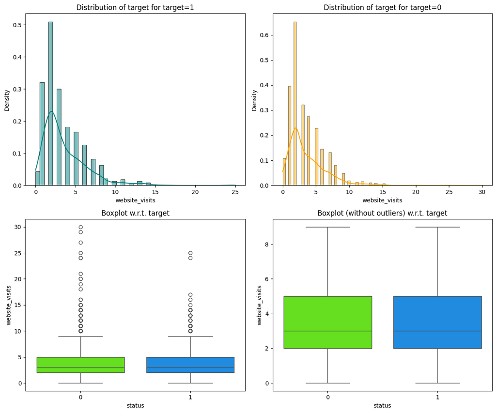

```python
# plot distribution for website_visits and status
distribution_plot_wrt_target(data, "website_visits", "status")
```

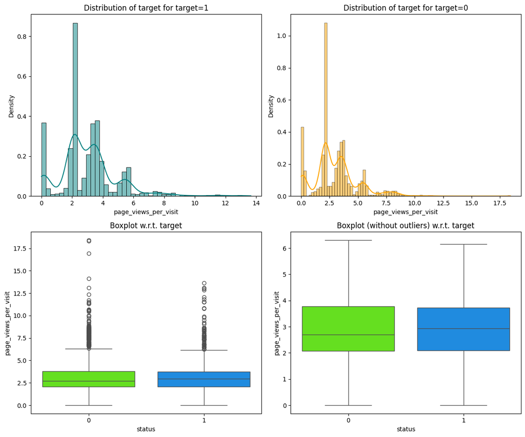

```python
# plot distribution for page_views_per_visit and status
distribution_plot_wrt_target(data, "page_views_per_visit", "status")
```

### Observations

1. Website visits and Page views per visit are very similar for both the converted and unconverted user base.
2. However, Time spent on website is 2.5x higher for converted users.

```
status                0     1   All
profile_completed
All                3235  1377  4612
High               1318   946  2264
Medium             1818   423  2241
Low                  99     8   107
------------------------------------------------------------------------------------------------------------------------
```

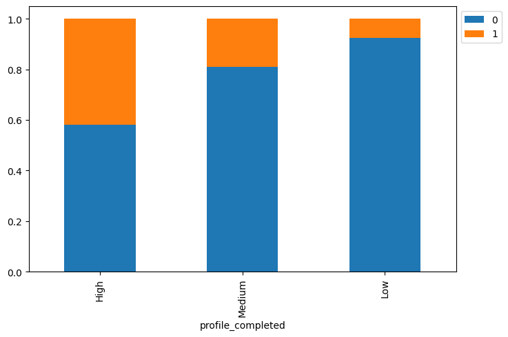

```python
# plot stacked_barplot for profile_completed and status
stacked_barplot(data, "profile_completed", "status")
```

After a lead shares their information by creating a profile, there may be interactions between the lead and the company to proceed with the process of enrollment. Let's see how the last activity impacts lead conversion status.

```
status               0     1   All
last_activity
All               3235  1377  4612
Email Activity    1587   691  2278
Website Activity   677   423  1100
Phone Activity     971   263  1234
------------------------------------------------------------------------------------------------------------------------
```

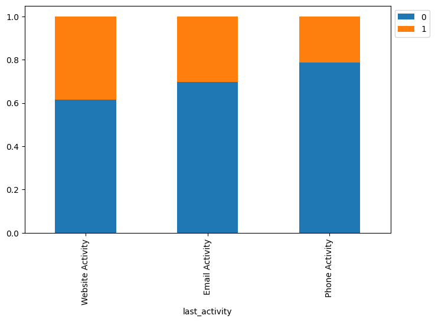

```python
# plot stacked_barplot for last_activity and status
stacked_barplot(data, "last_activity", "status")
```

Let's see how advertisement and referrals impact the lead status.

```
status                0     1   All
print_media_type1
All                3235  1377  4612
No                 2897  1218  4115
Yes                 338   159   497
------------------------------------------------------------------------------------------------------------------------
```

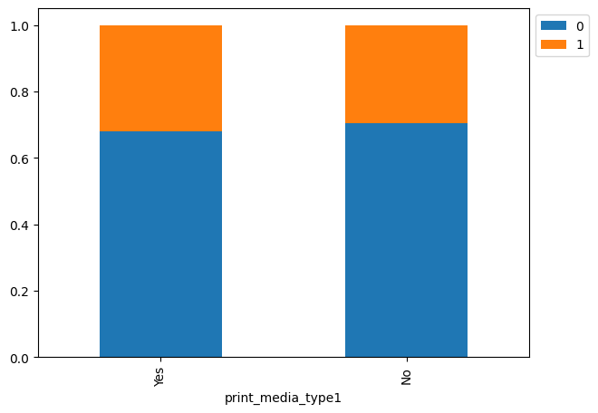

```python
# plot stacked_barplot for print_media_type1 and status
stacked_barplot(data, "print_media_type1", "status")
```

```
status                0     1   All
print_media_type2
All                3235  1377  4612
No                 3077  1302  4379
Yes                 158    75   233
------------------------------------------------------------------------------------------------------------------------
```

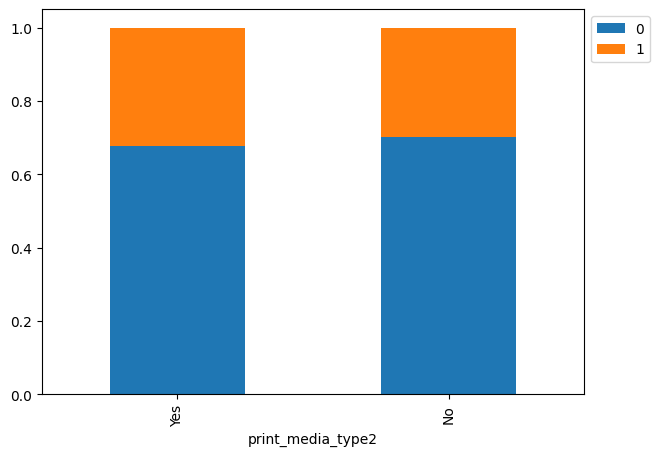

```python
# plot stacked_barplot for print_media_type2 and status
stacked_barplot(data, "print_media_type2", "status")
```

```
status            0     1   All
digital_media
All            3235  1377  4612
No             2876  1209  4085
Yes             359   168   527
------------------------------------------------------------------------------------------------------------------------
```

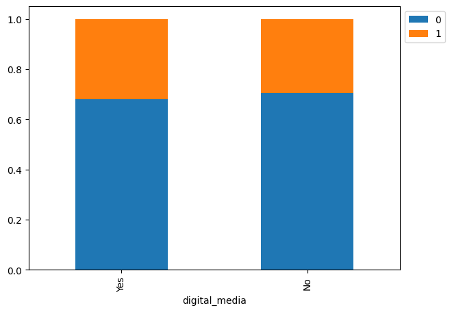

```python
# plot stacked_barplot for digital_media and status
stacked_barplot(data, "digital_media", "status")
```

```
status                   0     1   All
educational_channels
All                   3235  1377  4612
No                    2727  1180  3907
Yes                    508   197   705
------------------------------------------------------------------------------------------------------------------------
```

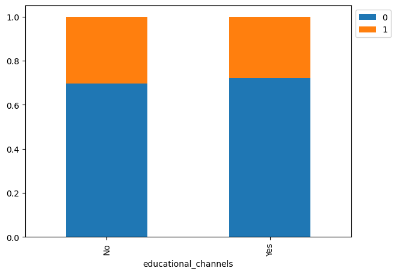

```python
# plot stacked_barplot for educational_channels and status
stacked_barplot(data, "educational_channels", "status")
```

```
status       0     1   All
referral
All       3235  1377  4612
No        3205  1314  4519
Yes         30    63    93
------------------------------------------------------------------------------------------------------------------------
```

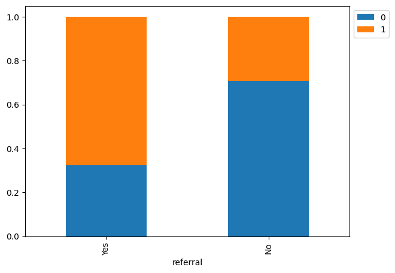

```python
# plot stacked_barplot for referral and status
stacked_barplot(data, "referral", "status")
```

### Observations

Listing below the conversion rate for different ad channels, where the user was exposed to ONLY one ad/channel. This will help in measuring effectiveness of that ad/channel.

Print media1 only: yes = 108, no = 235, Conversion rate = 31.4%

Print media2 only: yes = 41, no = 104, Conversion rate = 28.3%

Print media1 and media2 only: yes = 5, no = 16, Conversion rate = 23.8%

Digital Media only: yes = 114, no = 262, Conversion rate = 30.3%

Educational Channel only: yes = 139, no = 379, Conversion rate = 26.8%

Referral only: yes = 43, no = 17, Conversion rate = 71.7%

Referrals had a significant impact on conversion. Referrals converted at a much higher rate than non-referrals.

Professionals have the highest conversion rate.

Website has a higher conversion than the mobile app.

### Outlier Check

- Let's check for outliers in the data.

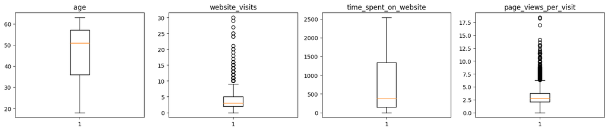

```python
# outlier detection using boxplot
numeric_columns = data.select_dtypes(include=np.number).columns.tolist()
# dropping release_year as it is a temporal variable
numeric_columns.remove("status")

plt.figure(figsize=(15, 12))

for i, variable in enumerate(numeric_columns):
    plt.subplot(4, 4, i + 1)
    plt.boxplot(data[variable], whis=1.5)
    plt.tight_layout()
    plt.title(variable)

plt.show()
```

### Observations

Majority of leads are over 35 years of age.

Majority of leads spend less than 1400 time on website.

There is a long tail of Website visits and Page views per visit.

### Data Preparation for modeling

- We want to predict which lead is more likely to be converted.
- Before we proceed to build a model, we will encode categorical features.
- We'll split the data into train and test to be able to evaluate the model that we build on the train data.

```python
# Print few observations to check categorical fields
data.sample(10)
```

|  | age | current_occupation | first_interaction | profile_completed | website_visits | time_spent_on_website | page_views_per_visit | last_activity | print_media_type1 | print_media_type2 | digital_media | educational_channels | referral | status |
| --- | --- | --- | --- | --- | --- | --- | --- | --- | --- | --- | --- | --- | --- | --- |
| 1978 | 49 | Professional | Mobile App | Medium | 5 | 354 | 3.257 | Phone Activity | No | No | No | No | No | 0 |
| 2996 | 60 | Professional | Website | Medium | 3 | 297 | 2.197 | Phone Activity | No | No | No | No | No | 0 |
| 1600 | 56 | Professional | Website | Medium | 3 | 12 | 7.077 | Email Activity | No | No | No | Yes | No | 0 |
| 3041 | 47 | Professional | Website | High | 7 | 1866 | 2.943 | Email Activity | No | No | No | No | No | 1 |
| 4436 | 37 | Unemployed | Mobile App | High | 1 | 333 | 2.190 | Phone Activity | No | No | No | Yes | No | 0 |
| 3770 | 55 | Unemployed | Mobile App | High | 3 | 2364 | 2.027 | Email Activity | Yes | No | No | Yes | No | 0 |
| 2219 | 48 | Professional | Mobile App | Medium | 2 | 103 | 3.753 | Email Activity | No | No | No | No | No | 0 |
| 878 | 56 | Professional | Mobile App | High | 0 | 0 | 0.000 | Email Activity | No | No | No | No | No | 0 |
| 2636 | 62 | Unemployed | Website | High | 4 | 286 | 2.067 | Website Activity | No | No | No | No | No | 0 |
| 207 | 24 | Student | Website | High | 2 | 1716 | 0.055 | Email Activity | Yes | No | No | No | No | 1 |

```python
# Encode the categorical features to numerical values
data["current_occupation"] = pd.factorize(data["current_occupation"].values)[0]
data["first_interaction"] = pd.factorize(data["first_interaction"].values)[0]
data["profile_completed"] = pd.factorize(data["profile_completed"].values)[0]
data["last_activity"] = pd.factorize(data["last_activity"].values)[0]
data["print_media_type1"] = pd.factorize(data["print_media_type1"].values)[0]
data["print_media_type2"] = pd.factorize(data["print_media_type2"].values)[0]
data["digital_media"] = pd.factorize(data["digital_media"].values)[0]
data["educational_channels"] = pd.factorize(data["educational_channels"].values)[0]
data["referral"] = pd.factorize(data["referral"].values)[0]

# Print few observations to check results of encoding
data.sample(10)
```

|  | age | current_occupation | first_interaction | profile_completed | website_visits | time_spent_on_website | page_views_per_visit | last_activity | print_media_type1 | print_media_type2 | digital_media | educational_channels | referral | status |
| --- | --- | --- | --- | --- | --- | --- | --- | --- | --- | --- | --- | --- | --- | --- |
| 2023 | 62 | 0 | 0 | 1 | 3 | 24 | 2.200 | 1 | 1 | 0 | 1 | 0 | 0 | 0 |
| 1610 | 56 | 1 | 1 | 0 | 1 | 2236 | 2.212 | 0 | 1 | 0 | 1 | 0 | 0 | 0 |
| 2706 | 50 | 1 | 0 | 0 | 2 | 2073 | 3.098 | 0 | 1 | 0 | 1 | 0 | 0 | 1 |
| 2346 | 38 | 1 | 1 | 1 | 2 | 75 | 3.383 | 1 | 1 | 0 | 0 | 0 | 0 | 0 |
| 1928 | 56 | 1 | 0 | 0 | 2 | 605 | 2.632 | 0 | 1 | 0 | 1 | 0 | 0 | 1 |
| 4131 | 46 | 0 | 1 | 0 | 6 | 1067 | 8.080 | 0 | 1 | 0 | 1 | 0 | 0 | 0 |
| 2601 | 21 | 2 | 1 | 1 | 2 | 1472 | 2.017 | 2 | 1 | 0 | 1 | 0 | 0 | 0 |
| 4192 | 54 | 0 | 1 | 0 | 5 | 2354 | 3.609 | 1 | 1 | 0 | 1 | 0 | 0 | 0 |
| 4411 | 46 | 1 | 0 | 1 | 4 | 652 | 2.890 | 1 | 1 | 0 | 0 | 0 | 0 | 1 |
| 1452 | 36 | 0 | 1 | 1 | 4 | 1666 | 3.718 | 2 | 1 | 0 | 1 | 1 | 0 | 0 |

### Split the dataset

```python
# Split the data set into training and test data
# 70% = training, 30% = test
train = data.sample(frac = 0.7, random_state = 1)
test = data.drop(train.index)

X_train = train[["age", "current_occupation", "first_interaction", "profile_completed", "website_visits", "time_spent_on_website", "page_views_per_visit", "last_activity", "print_media_type1", "print_media_type2", "digital_media", "educational_channels", "referral"]]
X_test = test[["age", "current_occupation", "first_interaction", "profile_completed", "website_visits", "time_spent_on_website", "page_views_per_visit", "last_activity", "print_media_type1", "print_media_type2", "digital_media", "educational_channels", "referral"]]

y_train = train["status"]
y_test = test["status"]
```

```python
print("Shape of Training set: ", X_train.shape)
print("Shape of test set: ", X_test.shape)
print("Percentage of classes in training set:")
print(y_train.value_counts(normalize=True))
print("Percentage of classes in test set:")
print(y_test.value_counts(normalize=True))
```

```
Shape of Training set:  (3228, 13)
Shape of test set:  (1384, 13)
Percentage of classes in training set:
status
0    0.700434
1    0.299566
Name: proportion, dtype: float64
Percentage of classes in test set:
status
0    0.703757
1    0.296243
Name: proportion, dtype: float64
```

## **Building Classification Models**

### Model evaluation criterion

### Model can make wrong predictions as:

1. Predicting a lead will not be converted to a paid customer in reality, the lead would have converted to a paid customer.
2. Predicting a lead will be converted to a paid customer in reality, the lead would not have converted to a paid customer.

### Which case is more important?

- If we predict that a lead will not get converted and the lead would have converted then the company will lose a potential customer.
- If we predict that a lead will get converted and the lead doesn't get converted the company might lose resources by nurturing false-positive cases.

Losing a potential customer is a greater loss.

### How to reduce the losses?

- Company would want `Recall` to be maximized, greater the Recall score higher are the chances of minimizing False Negatives.

#### First, let's create functions to calculate different metrics and confusion matrix so that we don't have to use the same code repeatedly for each model.

```python
# Function to print the classification report and get confusion matrix in a proper format

def metrics_score(actual, predicted):
    print(classification_report(actual, predicted))

    cm = confusion_matrix(actual, predicted)

    plt.figure(figsize = (8, 5))

    sns.heatmap(cm, annot = True,  fmt = '.2f', xticklabels = ['Not Converted', 'Converted'], yticklabels = ['Not Converted', 'Converted'])

    plt.ylabel('Actual')

    plt.xlabel('Predicted')

    plt.show()
```

## Decision Tree

### Building Decision Tree Model

```python
# Fitting the decision tree classifier on the training data
d_tree =  tree.DecisionTreeClassifier(criterion = 'entropy', max_depth = 5)

d_tree = d_tree.fit(X_train, y_train)
```

#### Checking model performance on training set

```
              precision    recall  f1-score   support

           0       0.89      0.92      0.91      2261
           1       0.80      0.73      0.76       967

    accuracy                           0.87      3228
   macro avg       0.85      0.83      0.84      3228
weighted avg       0.86      0.87      0.86      3228
```

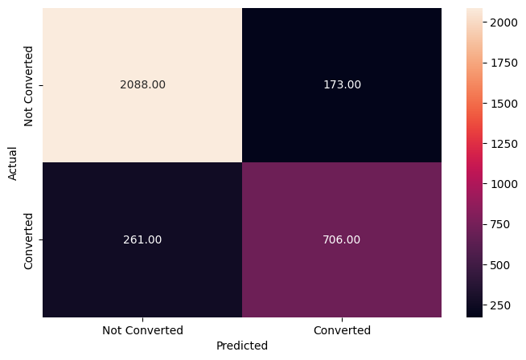

```
None
```

```python
# Checking performance on the training data
y_pred_train1 = d_tree.predict(X_train)

accuracy = metrics_score(y_train, y_pred_train1)
print(accuracy)
```

```
              precision    recall  f1-score   support

           0       0.89      0.93      0.91       974
           1       0.80      0.72      0.76       410

    accuracy                           0.86      1384
   macro avg       0.84      0.82      0.83      1384
weighted avg       0.86      0.86      0.86      1384
```

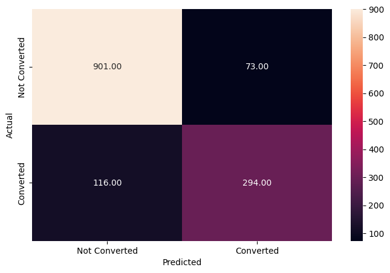

```
None
```

```python
# Check performance on the test data to see if the model is overfitting
y_pred_test1 = d_tree.predict(X_test)

accuracy = metrics_score(y_test, y_pred_test1)
print(accuracy)
```